# INITITATION AU MACHINE LEARNING_2025

#### Aide Markdown en ligne:

- [official_doc1_markdown](https://www.markdownguide.org/)
- [official_doc2_markdown](https://daringfireball.net/projects/markdown)
- [Tables_generators](https://www.tablesgenerator.com/markdown_tables)
- [Math_in_markdown](https://ens-fr.gitlab.io/mkdocs/maths/#:~:text=Il%20y%20a%20deux%20fa%C3%A7ons,ici%3E%24%20du%20texte%20apr%C3%A8s.)

# 1- MANIPULATION DES DONNEES AVEC PANDAS

**Tout savoir [Ici](https://www.w3schools.com/python/pandas/default.asp) sur Pandas**

**Et [Ici](https://www.geeksforgeeks.org/boolean-indexing-in-pandas/) pour mieux comprendre le Boolean indexing avec Pandas**

**Evaluation [Kahoot](https://create.kahoot.it/my-library/kahoots/35b2d71f-0d9f-48c3-86ee-c4fe2c31dab7)**

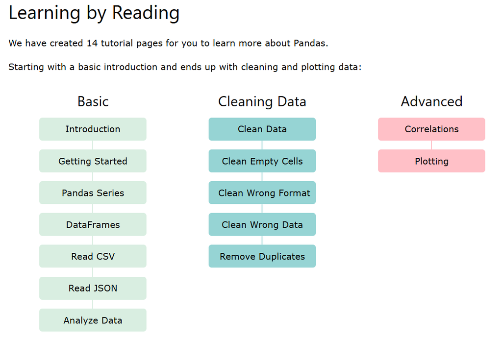

**Telecharger également [Ici](https://pandas.pydata.org/Pandas_Cheat_Sheet.pdf) le pandas cheat sheet**

[figure not shown]

# 2- DATA VIZ AVEC MATPLOTLIB, SEABORN, PLOTLY

**Tout savoir [Ici](https://www.simplilearn.com/tutorials/python-tutorial/data-visualization-in-python#:~:text=Matplotlib%20and%20Seaborn%20are%20python,primarily%20used%20for%20statistical%20graphs) sur Matplotlib**

**Tout savoir [Ici](https://www.geeksforgeeks.org/data-visualization-with-python/) sur Matplotlib, Seaborn et Plotly**

**Tout savoir [Ici](https://medium.com/@sawsanyusuf/data-visualization-with-python-11-plotly-express-59503cab2445) sur Plotly**

# 3- INITIATION AU MACHINE LEARNING

### Un peu d'histoire...

En 2020 Netflix affichait un chiffre d'affaire de 25 milliards de dollars pour 200 millions d'abonnés à travers le monde. Mais Netflix est sans doute la première entreprise dans les médias à prendre le traitement des données au sérieux, à chaque fois que vous en tant que client faites un evenement sur la plateforme , elle l'enregistre et le traite. Par exemple pour chaque abonnés vous avez,

- Le type de film ou séries que vous regardez,
- Lorsque vous mettez pause, revenez vous en arrière ou passez rapidement?
- La façon dont vous regardez une série( premier visionnage sans lendemain, visionnage dans son integralité, boulimique ou étalé,etc...),
- Le jour et l'heure de votre visionnage
- L'appareil utilisé,
- Votre évaluation sur l'application
- Le type de recherche que vous faites sur leur moteur,
- Etc...

Plusieurs informations pour des millions d'abonnées, on parle donc ici de **Big Data**.

### Le Big data qu'est ce que c'est ?

Depuis les années 2000, le terme *Big Data* a connu un certain succès, pour finalement devenir un concept phare dans le domaine du traitement de données. Ainsi le big data se défini donc comme des masses de données à la fois structurées et non structurées, générées souvent en flux continu, stockées dans des data lakes et qui pourraient être interprétées en quasi-temps réel.

Afin de caractériser ce type de données, les << 3V du Big Data >> ont été popularisés par le cabinet d'étude Gartner :

**1. Volume** : Le volume de données produites est considérable et sa croissance est exponentielle. Les soures de données se multiplient, avec Internet et les IOT.

**2. Vélocité** : C'est la rapidité de production des données, les base de données traditionnelles étaient relativement stables, s'incrementant progressivement au fur et à mesure de l'enregistrement de données. Ici les données sont produites de façon automatique ou semi-automatique et de manière continue en fonction du trafic sur un site, de l'utilisation d'un objet, de l'enregistrement des activités commerciales, etc. L'enjeu est de traiter ces données à la volée.

**3. Variété** : Les données traditionneelles étaient structurées alors que la plupart de celles dont on dispose aujourd'hui ne le sont plus (texte, image, sons, vidéos, etc...). Les outils de traitement peuvent donc faire apppel aux techniques de reconnaissance visuelle par exemple, ou de traitement de la voix. La difficulté est d'exploiter des masses d'information aussi variées.

Remarque : A ces V l'on peut ajouter la **Valeur** et la **Véracité** si l'on veut parler des 5 V's du Big Data

### A quoi sert le Big Data ?

Le Big data va aider les entreprises dans diverses activités telles que :

**Le marketing**: avec la grande quantité de données analysée, il est possible de mieux cerner les clients et prospects et ainsi d’adapter et personnaliser le contenu et les communications que leur seront dédiés.

**Le développement d’un produit**: en effet, les données récoltées vont permettre d’anticiper la demande des clients puisqu’elles modélisent de nouveaux produits selon les nouvelles innovations et les succès commerciaux.

**L’expérience client**: avec la Big Data, les entreprises disposent d’une meilleure visibilité sur l’expérience de leurs clients et elles peuvent donc proposer des services plus adaptés et traiter plus efficacement les problèmes qu’ils rencontrent.

**Améliorer l’utilisation des machines et autres appareils** : grâce à la Big Data, les entreprises peuvent désormais analyser et évaluer leur production de sorte à être capable d’anticiper d’éventuelles pannes et tenter de les réduire.

**Anticiper la demande client**: avec l’analyse des données de la Big Data, il est possible de prédire la demande future au vu de l’analyse du marché, de la demande passée et de bien d’autres facteurs. etc.

### Mais comment ? Grace à la Data Science...

La science des données plus connu sous le nom data science, est la discipline qui s'appuyant sur les statistiques, les mathématiques et l'informatique, consiste à colecter, agréger, nettoyer et classer les données pour ensuite les analyser, les interpreter, mettre en place des algorithmes traitant ces données afin d'en sortir des insights.

Et donc la data science est la science qui permet d'analyser les données du big data.

Plusieurs métiers en découlent et dont les plus connu sont entre autres:

**Data Scientist** : qui a pour rôle d'analyser de grands ensembles de données pour extraire des insights et des tendances significatives. Concevoir, développer et mettre en œuvre des modèles prédictifs et des algorithmes statistiques pour résoudre des problèmes métier.

**Data Engineer** : qui a pour rôle de concevoir, construire et entretenir les infrastructures de données et les pipelines pour recueillir, stocker, et traiter les données. Assurer la qualité et la fiabilité des données.

**Business Analyst**: Le Business Analyst fait le lien entre les besoins métier et les solutions techniques. Il analyse les processus, identifie les besoins, rédige les spécifications et accompagne le projet jusqu’à sa mise en œuvre.

**Data Analyst** : qui a pour rôle d'explorer et analyser les données pour identifier des tendances, des modèles et des insights qui peuvent être utilisés pour prendre des décisions commerciales. Créer des rapports et des visualisations de données pour communiquer les résultats.

**Data Architect** : qui a pour rôle de concevoir et gérer l'architecture des systèmes et des bases de données pour assurer la qualité, la sécurité et la scalabilité des données. Définir les normes et les bonnes pratiques en matière de gestion des données.

**Data Product Manager** : est responsable de la valeur des produits data (datasets, dashboards, APIs, algorithmes, plateformes…) qu’il conçoit pour répondre aux besoins métiers tout en assurant leur viabilité technique et leur impact business. Il est le chef d’orchestre entre les équipes data (data engineers, data scientists, data analysts), les métiers et parfois les équipes tech classiques..

Et donc faire de la data science ne consiste pas seulement à faire de la collecte, du stockage, de la description et de l'analyse de données, il y'a aussi un volet qui consiste à déterminer les schémas sous-jacents existant dans les données pour ensuite les utiliser afin d'effectuer des pronostics concernant de nouveaux exemples. On parle donc d'apprentissage automatique ou de *machine learning*

## Machine learning...

#### Qu'est ce que le machine learning ?

De façon simple le machine learning c'est :

- Un vaste ensembles d'outils pour modéliser et comprendre les données complexes
- le fait de comprendre et apprendre un comportement à partir d'exemples dans le but de faire des prédictions, des classifications ou prendre des décisions automatiques.

Se référer à *[Machine learning,Laurent Rouviere,Septembre 2020](https://lrouviere.github.io/machine_learning/cours.pdf)* pour plus de détail

🤷‍♂️**Comment cela fonctionne de façon simple?**

1. On collecte des données et faire l'EDA
   - Exemples : des mails (spam ou non), des images (chat ou chien), des historiques d’achats, etc.
2. On entraîne un modèle et tuner un modèle
   - C’est un algorithme qui analyse les données pour en déduire des patterns (motifs récurrents).
3. On teste le modèle
   - Il est confronté à de nouvelles données pour voir s’il peut faire des prédictions fiables.
4. On l’améliore avec le temps
   - Plus il a de données (et de qualité), plus il devient performant.

📚**Les grandes familles de Machine Learning :**

[figure not shown]

**Apprentissage par renforcement plus en détail...**

Le principe de base est qu'un agent intelligent prend des décisions dans un environnement. À chaque action qu’il effectue, il reçoit une récompense (positive ou négative). Le but de l’agent est d’apprendre une stratégie (policy) qui maximise la récompense cumulée sur le long terme ainsi l’agent apprend avec le temps quelles actions donnent les meilleures récompenses. .

Par exemple dans un jeu vidéo, l'agent c'est le joueur, l'environnement c'est le monde du jeu, l'objectif est de marquer le plus possible, les actions sont aller à gauche/droite, sauter, attaquer etc... et les récompenses +10pts pour une victoire et -5pts pour une défaite.

les algorithmes célèbres sont entre autres :

👉**Q-Learning** (tabulaire ou deep)

Le Q-Learning est un algorithme d’apprentissage par renforcement qui permet à un agent d’apprendre la meilleure action à prendre dans chaque situation, en maximisant les récompenses qu’il reçoit au fil du temps le but final est de construire une politique optimale en choisissant toujours l’action qui donne la meilleure récompense cumulée à long terme.

**⚙️ Comment ça marche ?**

1. L’agent explore un environnement en faisant des actions.
2. À chaque action, il observe :
   - le nouvel état atteint,
   - la récompense reçue.
3. Il met à jour une Q-table, qui enregistre la qualité (Q) de chaque action dans chaque état.
4. Avec le temps, il apprend quelle action est la meilleure à chaque étape.

La formule clé de mise à jour du Q est

$$Q(s,a)←Q(s,a)+α[r+γ max_aQ(s',a)−Q(s,a)]$$

avec

- s : état actuel
- a : action choisie
- r : récompense reçue
- s′: nouvel état
- α : taux d’apprentissage (Learning rate)
- γ : facteur de discount (Importance des récompenses futures) ( Trop faible → Apprend juste pour l'immédiat, Trop élevé → Prend des décisions à long terme)

**📦 Exemples :**

- Un robot qui apprend à sortir d’un labyrinthe.
- Un jeu vidéo où l’IA apprend à gagner.
- Une voiture autonome qui apprend à éviter les obstacles.

voir un exemple Reinforement Learning exemple (Q-Table).IPYNB

👉 **Deep Q-Networks (DQN)** → RL + réseaux de neurones

👉 **Policy Gradient** (REINFORCE, PPO, etc.)

👉 **Actor-Critic**

👉 **...**

### **Quelques hyperparamètres et métriques bon à connaitre**

### **==> Learning Rate**

Le learning rate (taux d'apprentissage) est un paramètre fondamental en machine learning, qui détermine la vitesse à laquelle un modèle ajuste ses paramètres pendant l'apprentissage.

Lorsqu'on entraîne un modèle, le but est de minimiser une fonction de coût (ou fonction de perte), qui mesure l'écart entre les prédictions du modèle et les valeurs réelles. Le learning rate contrôle la taille des ajustements effectués sur les paramètres du modèle (comme les poids d'un réseau de neurones) pour réduire cette erreur à chaque étape.

📈 En clair :

➤ Si le learning rate est trop grand (α = 1 par exemple) :

Le modèle apprend vite, mais risque de sauter d’un extrême à l’autre (instable).

"Si tu fais des pas trop grands, tu risques de tomber dans un trou sans y arriver."

➤ Si le learning rate est trop petit (α = 0.001) :

Le modèle apprend lentement, il met beaucoup de temps à converger.

"Si tu fais des pas trop petits, tu peux finir par ne jamais atteindre ton objectif."

🔧 Choisir un bon learning_rate :

En pratique : souvent entre 0.01 et 0.1 pour les algos simples.

Tu peux aussi le réduire au fil du temps (pour stabiliser l’apprentissage).

### **==> p-value**

La p-value est une probabilité qui mesure la force de l'évidence contre l'hypothèse nulle $(𝐻_0)$ dans un test statistique. Elle permet de savoir si les résultats observés sont suffisamment significatifs pour rejeter l'hypothèse nulle.

- p-value faible (généralement < 0.05) : Il y a une forte évidence contre l'hypothèse nulle. On peut donc rejeter l'hypothèse nulle.
- p-value élevée (généralement > 0.05) : Il n'y a pas de preuve suffisante pour rejeter l'hypothèse nulle. Cela signifie que les données observées ne sont pas suffisamment différentes de ce que l'on attend sous $𝐻_0$

En Regression Linéaire/Logistique, la p-value est utilisée pour tester si chaque variable (feature) a un effet significatif sur la variable cible.Elle permet donc de :

- Faire de la sélection de variables.
- Interpréter l’importance d’une feature.
- Savoir si une relation est statistiquement significative.

Par exemple si l'on fait un modèle $\text{Prix de la maison} = α_1 * \text{surface} + α_2 * \text{nombre de chambres} + α_3 * \text{âge} + \epsilon $ et que la p_value de l'âge est supérieur à 0,05, cela voudra dire que âge n’explique pas significativement le prix de la maison.

En machine learning, la p-value est surtout utilisée dans les modèles explicatifs (comme la régression), mais pas dans les modèles prédictifs complexes où l’interprétation statistique classique ne s’applique pas directement.

### **==> Seuil de décision(decision threshold)**

Dans une classification, c’est la valeur à partir de laquelle on décide si une observation appartient à la classe positive ou négative, à partir d'une probabilité prédite.

🧠 Concrètement : Un modèle de classification (ex : régression logistique, arbre, réseau de neurones…) prédit souvent une probabilité pour chaque classe.

Par défaut, on utilise souvent un seuil de 0.5 :

`if probabilité > 0.5: prédiction = classe 1 (positive) else: prédiction = classe 0 (négative)`

### ⚖️ Pourquoi c’est important ?

**🔻Baisser le seuil :**

**✅ Augmente le rappel** : on capte plus de positifs

**❌ Risque plus de faux positifs**

👉 Exemple : détection de fraude, cancer → mieux vaut être trop sensible

**🔺Monter le seuil :**

**✅ Augmente la précision :** on est plus sûr quand on dit "positif"

**❌ On peut rater des vrais positifs**

👉 Exemple : condamnation juridique → mieux vaut ne pas accuser à tort

### **==> Accuracy(Taux de bon classement)**

Le taux de bon classement représente le pourcentage de bonnes prédictions faites par ton modèle sur un ensemble de données. Sa formumle est :

$$ \text{Taux de bon classement (Accuracy)} = \dfrac{\text{Nombre de bonnes prédictions}}{\text{Nombre total de prédictions}}$$

Dans le cas des données déséquilibrées l'accuracy n'est pas une bonne métrique.

### **==> Matrice de confusion**

C’est un tableau qui compare les prédictions du modèle avec les valeurs réelles.

[figure not shown]

- $\text{VP = Vrai Positif}$
- $\text{FP = Faux Positif}$
- $\text{VN = Vrai Négatif}$
- $\text{FN = Faux Négatif}$

### **==> Précision**

Sur tout ce que le modèle a dit être "positif", combien l’étaient vraiment ?

$$ \text{Précision} = \dfrac{\text{VP}}{\text{VP + FP}}$$

Utile quand tu veux éviter les faux positifs. Exemple : diagnostic médical → tu veux pas dire à quelqu’un qu’il a une maladie s’il ne l’a pas.

### **==> Rappel**

Combien de vrais positifs présent dans les données le modèle a-t-il bien trouvés ? $$ \text{Rappel} = \dfrac{\text{VP}}{\text{VP + FN}}$$

Utile quand tu veux éviter de rater des vrais positifs. Exemple : détecter tous les cas de fraude, même si ça génère des faux positifs.

### **==> F1-score : compromis entre précision et rappel**

$$ \text{F1} = 2* \dfrac{\text{Précision}*\text{Rappel} }{\text{Précision + Rappel}}$$

Il est utile quand tu veux un équilibre entre précision et rappel, surtout si les classes sont déséquilibrées.

### **==> Courbe ROC (Receiver Operating Characteristic) et AUC (Area Under the Curve)**

La courbe ROC trace le rappel (true positive rate) en fonction du faux positif rate, pour tous les *seuils de classification* possibles. Ils permettent d'évaluer la capacité du modèle à discriminer surtout lorsque les classes sont déséquilibrées.

- Axe des Y : Taux de vrais positifs (TPR ou Recall)
- Axe des X : Taux de Faux positifs (FPR)

$$ \text{FPR} = \dfrac{\text{FP}}{\text{FP + VN}}$$

l'AUC c'est l’aire sous la courbe ROC, donc un score entre 0 et 1.

Si;

- **AUC = 1.0** → modèle parfait.
- **AUC = 0.5** → modèle aléatoire.
- **AUC < 0.5** → modèle pire qu’aléatoire 😬 (il se trompe systématiquement).

🧠 Pourquoi ROC + AUC sont utiles ?

- Contrairement à l'accuracy, ils ne dépendent pas d’un seul seuil de décision (comme 0.5).
- Très utiles en cas de classes déséquilibrées.
- Permettent de comparer plusieurs modèles facilement.

### ==> Biais (Bias)

Le biais, c’est l’erreur due à un modèle trop simple pour capturer la complexité des données.

**🧠 En d'autres mots :**

Ton modèle a une vision trop rigide.

Il fait des suppositions fortes, comme “la relation est forcément linéaire”.

Cela cause une erreur systématique : même sur beaucoup de données, il ne s’améliore pas vraiment.

**📉 Exemple :**

Un modèle de régression linéaire qui essaie de prédire un phénomène clairement non linéaire = biais élevé

### ==> Variance

La variance, c’est l’erreur due à un modèle trop sensible aux fluctuations des données d’entraînement.

**🧠 En d'autres mots :** Ton modèle colle trop aux données, même au bruit ou aux anomalies.

Il s’adapte trop, donc change beaucoup selon les données qu’il voit.

Il fonctionne bien sur l’entraînement, mais mal sur des données nouvelles (test) → overfitting.

**📉 Exemple :** Un modèle avec beaucoup de neurones, ou un arbre de décision trop profond = variance élevée

### ==> Le compromis biais-variance (bias-variance tradeoff)

C’est l’équilibre à trouver pour minimiser l’erreur totale.

$$\text{Erreur totale} = \text{Biais²} + \text{Variance} + \text{Bruit irréductible}$$

En résumé;

[figure not shown]

### **==> 🌄 Descente de Gradient (Gradient Descent)**

**Définition :** La descente de gradient est une méthode d’optimisation numérique très utilisée en Machine Learning pour ajuster les paramètres (poids) d’un modèle afin de minimiser une fonction de coût (ou fonction de perte).

C’est un peu comme descendre une montagne à pied, en suivant la pente la plus raide pour atteindre le point le plus bas possible (le minimum de la fonction de coût).

**🎯 Objectif :** Trouver les meilleurs paramètres $\beta$ $(\text{ou les poids w})$, qui minimisent la fonction de coût $J(\beta)$, c’est-à-dire rendre l’erreur entre les prédictions du modèle et les vraies valeurs aussi petite que possible.

⚙️ Principe : À chaque itération, on met à jour les paramètres en suivant la pente (le gradient) de la fonction de coût, dans la direction opposée au gradient (car on cherche à minimiser la fonction).

**🔢 Formule de mise à jour des paramètres :** $$\beta := \beta - \alpha ∇ J(\beta)$$

où;

- $\beta \text{ : les paramètres du modèle.}$
- $\alpha \text{ : taux d'apprentissage (learning rate) — détermine la taille du pas.}$
- $∇ J(\beta) \text{ : gradient de la fonction de coût (la dérivée partielle pour chaque paramètre).}$

**Exemple (régression linéaire)**

Imaginons qu'on veut ajuster un modèle linéaire simple:

$$\hat{y} = \beta_0 +\beta_1x $$

On minimise la fonction coût (par ex. l’erreur quadratique moyenne) avec la descente de gradient :

$$J(\beta) = \frac{1}{2m}\sum_{i=1}^{m}(\hat{y_i}-y_i)^2$$

Les dérivées (gradients) sont :

$$\frac{\delta J}{\delta \beta_0} = \frac{1}{m}\sum_{i=1}^{m}(\hat{y_i}-y_i) $$$$\frac{\delta J}{\delta \beta_1} = \frac{1}{m}\sum_{i=1}^{m}(\hat{y_i}-y_i) x_{i} $$

On met à jour $\beta_0$ et $\beta_1$ et à chaque itération avec ces gradients en cherchant les minimums.

**📦 Types de descente de gradient :**

| Type | Description |
| --- | --- |
| Batch Gradient Descent | Utilise toutes les données pour chaque mise à jour. Lent pour grands datasets mais stable. |
| Stochastic Gradient Descent (SGD) | Utilise une seule observation à chaque itération. Rapide mais bruité. |
| Mini-batch Gradient Descent | Utilise un sous-ensemble (batch) de données. Bon compromis entre vitesse et stabilité. |

### **USE CASE1 : Scoring d'appétence basé sur le dataset Adulte income**

📚 Présentation du dataset Adult Income

Le dataset contient des informations démographiques et professionnelles d'individus, avec pour objectif de prédire si leur revenu annuel dépasse 50 000 $.

📊 Détails clés : Instances : 48 842

Attributs : 14 (dont 6 numériques et 8 catégoriels)

Cible : >50K ou <=50K (revenu annuel)

🧠 Colonnes principales :

- age : Âge (numérique)
- workclass : Type de travail (catégoriel)
- fnlwgt : Poids final (numérique)
- education : Niveau d'éducation (catégoriel)
- education-num : Nombre d'années d'éducation (numérique)
- marital-status : Statut marital (catégoriel)
- occupation : Profession (catégoriel)
- relationship : Relation familiale (catégoriel)
- race : Race (catégoriel)
- sex : Sexe (catégoriel)
- capital-gain : Gain en capital (numérique)
- capital-loss : Perte en capital (numérique)
- hours-per-week : Heures travaillées par semaine (numérique)
- native-country : Pays d'origine (catégoriel)
- class : Revenu annuel (>50K ou <=50K)

```python
#Charger les librairies
import pandas as pd
import numpy as np
from sklearn.model_selection import train_test_split, cross_val_score, StratifiedKFold
from sklearn.preprocessing import StandardScaler
from sklearn.linear_model import LogisticRegression
from sklearn.tree import DecisionTreeClassifier
from sklearn.ensemble import RandomForestClassifier
from sklearn.metrics import (accuracy_score, roc_auc_score, precision_score, recall_score,
                             f1_score, confusion_matrix, RocCurveDisplay)
import matplotlib.pyplot as plt
import seaborn as sns
```

```python
# Charger le dataset
url = "https://archive.ics.uci.edu/ml/machine-learning-databases/adult/adult.data"
columns = ["age", "workclass", "fnlwgt", "education", "education-num", "marital-status",
           "occupation", "relationship", "race", "sex", "capital-gain", "capital-loss",
           "hours-per-week", "native-country", "income"]

data = pd.read_csv(url, names=columns, na_values=' ?', skipinitialspace=True)
```

💡**skipinitialspace=True** permet d'ignorer les espaces après les virgules lors de la lecture d’un fichier CSV.

```python
data.head()
```

|  | age | workclass | fnlwgt | education | education-num | marital-status | occupation | relationship | race | sex | capital-gain | capital-loss | hours-per-week | native-country | income |
| --- | --- | --- | --- | --- | --- | --- | --- | --- | --- | --- | --- | --- | --- | --- | --- |
| 0 | 39 | State-gov | 77516 | Bachelors | 13 | Never-married | Adm-clerical | Not-in-family | White | Male | 2174 | 0 | 40 | United-States | <=50K |
| 1 | 50 | Self-emp-not-inc | 83311 | Bachelors | 13 | Married-civ-spouse | Exec-managerial | Husband | White | Male | 0 | 0 | 13 | United-States | <=50K |
| 2 | 38 | Private | 215646 | HS-grad | 9 | Divorced | Handlers-cleaners | Not-in-family | White | Male | 0 | 0 | 40 | United-States | <=50K |
| 3 | 53 | Private | 234721 | 11th | 7 | Married-civ-spouse | Handlers-cleaners | Husband | Black | Male | 0 | 0 | 40 | United-States | <=50K |
| 4 | 28 | Private | 338409 | Bachelors | 13 | Married-civ-spouse | Prof-specialty | Wife | Black | Female | 0 | 0 | 40 | Cuba | <=50K |

```python
#Suppression des lignes avec les valeurs manquantes
data.dropna(inplace=True)
#Mias attention, toujours faire une analyse exploratoire pour savoir s'il faut supprimer ou imputer les Valeurs manquantes.


# Convertir les variables catégorielles en variables fictives
data = pd.get_dummies(data, drop_first=True)
```

```python
## Separer les features et la variable Target
X = data.drop('income_>50K', axis=1)
y = data['income_>50K']
```

Nous sommes dans un cas de données fortement déséquilibré 75,92% de 0 pour la variable cible.

```python
# Spliter les données en entrainement et test
X_train, X_test, y_train, y_test = train_test_split(X, y, test_size=0.2, random_state=42, stratify=y)
```

```python
X_train
```

|  | age | fnlwgt | education-num | capital-gain | capital-loss | hours-per-week | workclass_Federal-gov | workclass_Local-gov | workclass_Never-worked | workclass_Private | ... | native-country_Portugal | native-country_Puerto-Rico | native-country_Scotland | native-country_South | native-country_Taiwan | native-country_Thailand | native-country_Trinadad&Tobago | native-country_United-States | native-country_Vietnam | native-country_Yugoslavia |
| --- | --- | --- | --- | --- | --- | --- | --- | --- | --- | --- | --- | --- | --- | --- | --- | --- | --- | --- | --- | --- | --- |
| 15738 | 32 | 37210 | 13 | 0 | 0 | 45 | False | False | False | True | ... | False | False | False | False | False | False | False | True | False | False |
| 27985 | 43 | 101950 | 14 | 0 | 0 | 45 | False | False | False | True | ... | False | False | False | False | False | False | False | True | False | False |
| 30673 | 20 | 122244 | 9 | 0 | 0 | 28 | False | False | False | False | ... | False | False | False | False | False | False | False | True | False | False |
| 9505 | 40 | 24763 | 10 | 6849 | 0 | 40 | False | True | False | False | ... | False | False | False | False | False | False | False | True | False | False |
| 26417 | 24 | 113936 | 13 | 0 | 0 | 40 | False | False | False | True | ... | False | False | False | False | False | False | False | True | False | False |
| ... | ... | ... | ... | ... | ... | ... | ... | ... | ... | ... | ... | ... | ... | ... | ... | ... | ... | ... | ... | ... | ... |
| 8003 | 35 | 179171 | 9 | 0 | 0 | 38 | False | False | False | False | ... | False | False | False | False | False | False | False | False | False | False |
| 20560 | 39 | 421633 | 10 | 0 | 0 | 30 | False | False | False | True | ... | False | False | False | False | False | False | False | True | False | False |
| 23650 | 55 | 82098 | 9 | 0 | 0 | 55 | False | False | False | True | ... | False | False | False | False | False | False | False | True | False | False |
| 25301 | 26 | 50053 | 13 | 0 | 0 | 55 | False | False | False | True | ... | False | False | False | False | False | False | False | True | False | False |
| 5800 | 19 | 415354 | 6 | 0 | 0 | 40 | False | False | False | True | ... | False | False | False | False | False | False | False | True | False | False |

26048 rows × 100 columns

```python
# Standardisation des variables
scaler = StandardScaler()
X_train = scaler.fit_transform(X_train)
X_test = scaler.transform(X_test)
```

```python
X_train
```

```
array([[-0.48306519, -1.44814967,  1.13054018, ...,  0.34097379,
        -0.0447248 , -0.01752768],
       [ 0.32334184, -0.83454879,  1.51766649, ...,  0.34097379,
        -0.0447248 , -0.01752768],
       [-1.36278194, -0.64220378, -0.41796503, ...,  0.34097379,
        -0.0447248 , -0.01752768],
       ...,
       [ 1.20305859, -1.02270456, -0.41796503, ...,  0.34097379,
        -0.0447248 , -0.01752768],
       [-0.92292356, -1.32642467,  1.13054018, ...,  0.34097379,
        -0.0447248 , -0.01752768],
       [-1.43609167,  2.13587088, -1.57934394, ...,  0.34097379,
        -0.0447248 , -0.01752768]])
```

```python
X_test
```

```
array([[-0.55637491, -0.68277877,  2.29191909, ...,  0.34097379,
        -0.0447248 , -0.01752768],
       [-1.36278194,  0.10888388, -0.03083872, ...,  0.34097379,
        -0.0447248 , -0.01752768],
       [ 2.88918236,  1.85047159,  1.13054018, ...,  0.34097379,
        -0.0447248 , -0.01752768],
       ...,
       [ 0.03010292,  0.11397353,  1.90479279, ...,  0.34097379,
        -0.0447248 , -0.01752768],
       [-0.70299437, -0.60683216, -0.41796503, ...,  0.34097379,
        -0.0447248 , -0.01752768],
       [-1.43609167,  1.72954275, -0.03083872, ...,  0.34097379,
        -0.0447248 , -0.01752768]])
```

💡**StandardScaler() – C’est quoi exactement ?** C’est une transformation qui standardise les données : elle centre et réduit chaque variable. Sans standardisation, une variable avec des valeurs très grandes peut dominer les autres, même si elle est moins importante.

Autrement dit, chaque colonne aura :

- une moyenne = 0
- un écart-type = 1

Il est pas toujours très nécessaire sauf pour certains modèles sont sensibles à l’échelle des données, car ils utilisent des distances ou des gradients comme par exemple :

| Algorithmes | A besoin de StandardScaler ? |
| --- | --- |
| KNN / K-means | ✅ Oui (utilise des distances) |
| SVM | ✅ Oui |
| Régression logistique | ✅ Souvent recommandé (les coefs sont souvent sensibles aux échelles) |
| Régression linéaire | ✅ Souvent recommandé (les coefs sont souvent sensibles aux échelles) |
| Arbre de décision | ❌ Non |
| Random Forest / XGBoost | ❌ Non |

💡**fit_transform() – C’est quoi exactement ?**

C’est une méthode combinée qui fait en une seule étape :

*1. fit() → Apprendre les paramètres (ex: moyenne, écart-type, min, max…),* et donc calcule la moyenne et l'écart-type dans notre cas

*2. transform() → Appliquer la transformation aux données,* et donc applique la standardisation après l'étape 1

💡**Quand utiliser fit_transform() vs transform() ?**

| Méthodes | Utiliser quand ? |
| --- | --- |
| fit_transform() | Sur le train set uniquement (pour apprendre + transformer) |
| transform() | Sur le test set ou de nouvelles données (en appliquant les stats du train set) |

**⚠️ Important :** Tu ne dois pas fit() sur les données de test ! Sinon, tu introduis du data leakage (fuite d'information) et une disparité d'échelle.

En effet le modèle est formé sur des données qui ont été normalisées ou standardisées, mais lorsqu'il est testé sur des données non transformées, les échelles des données d'entraînement et de test seront différentes. Cela peut entraîner des erreurs de calcul dans des modèles basés sur distances (comme KNN, SVM, régression logistique, etc.) ou affecter les coefficients dans des modèles comme la régression linéaire.

Aussi si tu appliques fit() sur les données de test lors de la transformation (par exemple, avec StandardScaler), tu risques de contaminer ton modèle avec des informations des données de test. C'est ce qu'on appelle du data leakage, qui peut influer sur la performance du modèle de manière irréaliste. En effet, tu ferais passer des informations provenant des données de test dans le processus d'entraînement, ce qui fausse l'évaluation réelle de la performance du modèle.

```python
# Initialisation de la cross-validation
cv = StratifiedKFold(n_splits=5, shuffle=True, random_state=42)
```

**La validation croisée (ou cross-validation)** est une méthode utilisée pour évaluer la performance d'un modèle, mais elle fait partie du processus d'entraînement, pas de test, bien que son objectif soit de simuler la phase de test sur plusieurs sous-ensembles des données.

Elle a pour but de valider la capacité de généralisation du modèle en évaluant sa performance sur des sous-ensembles distincts des données, afin de réduire le risque de sur-apprentissage (overfitting).

**🛠️ Processus de validation croisée :**

**1. Diviser les données :** Le dataset est divisé en K sous-ensembles (ou folds).

**2. Entraînement et test :** À chaque itération :

- Une portion des données est utilisée pour entraîner le modèle.
- Le modèle est testé sur une autre portion (le fold de test).

**3. Moyenne des scores :** Les scores (par exemple, précision, rappel, F1-score) obtenus à chaque itération sont moyennés pour donner une estimation plus fiable de la performance globale.

Que tout soit donc bien clair, la validation croisée fait partie du processus d'entraînement, car elle permet de former le modèle sur des sous-ensembles des données et de l'évaluer de manière plus robuste à chaque itération. Elle n'est pas une phase de test final en soi. L'évaluation finale de la performance se fait après l'entraînement, lorsque tu utilises le modèle sur des données qu'il n'a jamais vues auparavant (en général le test set séparé).

📊 En résumé :

- **Avant la validation croisée** : tu prépares ton modèle et définis des hyperparamètres.
- **Pendant la validation croisée** : tu entraînes ton modèle sur différentes portions des données et tu testes sa performance.
- **Après la validation croisée** : une fois le modèle ajusté, tu le testes une dernière fois sur un jeu de données de test qui n'a jamais été vu par le modèle.

```python
# Fonction permettant d'évaluer le modèle
def evaluate_model(model, X_train, y_train, X_test, y_test):
    model.fit(X_train, y_train)
    y_pred = model.predict(X_test)
    y_pred_proba = model.predict_proba(X_test)[:, 1]

    accuracy = accuracy_score(y_test, y_pred)
    precision = precision_score(y_test, y_pred)
    recall = recall_score(y_test, y_pred)
    f1 = f1_score(y_test, y_pred)
    auc = roc_auc_score(y_test, y_pred_proba)
    conf_matrix = confusion_matrix(y_test, y_pred)

    return accuracy, precision, recall, f1, auc, conf_matrix, y_pred_proba
```

```python
#  Regression Logisitque
lr_model = LogisticRegression(max_iter=1000)
lr_cv_scores = cross_val_score(lr_model, X_train, y_train, cv=cv, scoring='roc_auc')
accuracy_lr, precision_lr, recall_lr, f1_lr, auc_lr, conf_matrix_lr, y_pred_proba_lr = evaluate_model(lr_model, X_train, y_train, X_test, y_test)

print('Regression Logistique:')
print(f'  CV AUC-ROC: {lr_cv_scores.mean()}')
print(f'  Test AUC-ROC: {auc_lr}\n')
print(f'  Test Accuracy: {accuracy_lr}')
print(f'  Test Precision: {precision_lr}')
print(f'  Test Recall: {recall_lr}')
print(f'  Test F1-Score: {f1_lr}')
```

```
Regression Logistique:
  CV AUC-ROC: 0.9055963230715438
  Test AUC-ROC: 0.9093325044881451

  Test Accuracy: 0.8550591125441425
  Test Precision: 0.7367223065250379
  Test Recall: 0.6192602040816326
  Test F1-Score: 0.6729036729036729
```

```python
# Arbre de décision
dt_model = DecisionTreeClassifier()
dt_cv_scores = cross_val_score(dt_model, X_train, y_train, cv=cv, scoring='roc_auc')
accuracy_dt, precision_dt, recall_dt, f1_dt, auc_dt, conf_matrix_dt, y_pred_proba_dt = evaluate_model(dt_model, X_train, y_train, X_test, y_test)

print('Arbre de décision:')
print(f'  CV AUC-ROC: {dt_cv_scores.mean()}')
print(f'  Test Accuracy: {accuracy_dt}')
print(f'  Test Precision: {precision_dt}')
print(f'  Test Recall: {recall_dt}')
print(f'  Test F1-Score: {f1_dt}')
print(f'  Test AUC-ROC: {auc_dt}\n')
```

```
Arbre de décision:
  CV AUC-ROC: 0.7439976419848826
  Test Accuracy: 0.8145247965607247
  Test Precision: 0.608433734939759
  Test Recall: 0.6441326530612245
  Test F1-Score: 0.6257744733581165
  Test AUC-ROC: 0.7563433740533625
```

```python
# Random Forest
rf_model = RandomForestClassifier()
rf_cv_scores = cross_val_score(rf_model, X_train, y_train, cv=cv, scoring='roc_auc')
accuracy_rf, precision_rf, recall_rf, f1_rf, auc_rf, conf_matrix_rf, y_pred_proba_rf = evaluate_model(rf_model, X_train, y_train, X_test, y_test)

print('Random Forest:')
print(f'  CV AUC-ROC: {rf_cv_scores.mean()}')
print(f'  Test Accuracy: {accuracy_rf}')
print(f'  Test Precision: {precision_rf}')
print(f'  Test Recall: {recall_rf}')
print(f'  Test F1-Score: {f1_rf}')
print(f'  Test AUC-ROC: {auc_rf}\n')
```

```
Random Forest:
  CV AUC-ROC: 0.9024510777091772
  Test Accuracy: 0.8595117457392907
  Test Precision: 0.7420311341734618
  Test Recall: 0.6383928571428571
  Test F1-Score: 0.6863215632499143
  Test AUC-ROC: 0.9076808541920307
```

[figure not shown]

```python
# Traçons à présent la matrice de confusion
fig, axes = plt.subplots(1, 3, figsize=(18, 5))
sns.heatmap(conf_matrix_lr, annot=True, fmt='d', ax=axes[0], cmap='Blues')
axes[0].set_title('Regression Logistique\nMatrice de Confusion')
axes[0].set_xlabel('Predicted')
axes[0].set_ylabel('Actual')

sns.heatmap(conf_matrix_dt, annot=True, fmt='d', ax=axes[1], cmap='Blues')
axes[1].set_title('Arbre de décision\nMatrice de Confusion')
axes[1].set_xlabel('Predicted')
axes[1].set_ylabel('Actual')

sns.heatmap(conf_matrix_rf, annot=True, fmt='d', ax=axes[2], cmap='Blues')
axes[2].set_title('Random Forest\nMatrice de Confusion')
axes[2].set_xlabel('Predicted')
axes[2].set_ylabel('Actual')

plt.tight_layout()
plt.show()
```

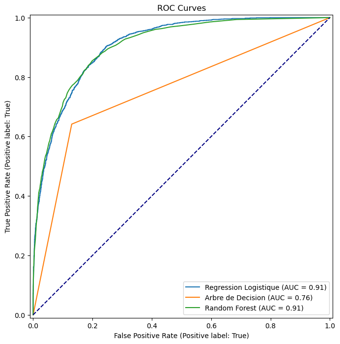

```python
# Traçons la courbe ROC
fig, ax = plt.subplots(figsize=(10, 8))
RocCurveDisplay.from_estimator(lr_model, X_test, y_test, ax=ax, name='Regression Logistique')
RocCurveDisplay.from_estimator(dt_model, X_test, y_test, ax=ax, name='Arbre de Decision')
RocCurveDisplay.from_estimator(rf_model, X_test, y_test, ax=ax, name='Random Forest')
plt.plot([0, 1], [0, 1], color='navy', linestyle='--')
plt.title('ROC Curves')
plt.show()
```

```python
# Prediction et scoring de nouvelle donnée
# Ici, nous utiliserons les données du test elles-mêmes pour démontrer le scoring

#Avec le Random forest
new_scores = rf_model.predict_proba(X_test)[:, 1]
X_test_df = pd.DataFrame(X_test, columns=X.columns)  # reconvertir en DataFrame pour enregistrer
X_test_df['appetence_score'] = new_scores
X_test_df.to_csv('scored_data.csv', index=False)
```

[output not shown]

```python
X_test_df
```

|  | age | fnlwgt | education-num | capital-gain | capital-loss | hours-per-week | workclass_Federal-gov | workclass_Local-gov | workclass_Never-worked | workclass_Private | ... | native-country_Puerto-Rico | native-country_Scotland | native-country_South | native-country_Taiwan | native-country_Thailand | native-country_Trinadad&Tobago | native-country_United-States | native-country_Vietnam | native-country_Yugoslavia | appetence_score |
| --- | --- | --- | --- | --- | --- | --- | --- | --- | --- | --- | --- | --- | --- | --- | --- | --- | --- | --- | --- | --- | --- |
| 0 | -0.556375 | -0.682779 | 2.291919 | -0.145319 | -0.217362 | -0.038714 | -0.173947 | -0.264569 | -0.015179 | -1.508937 | ... | -0.059535 | -0.017528 | -0.051161 | -0.041135 | -0.020554 | -0.024004 | 0.340974 | -0.044725 | -0.017528 | 0.120 |
| 1 | -1.362782 | 0.108884 | -0.030839 | -0.145319 | -0.217362 | -0.038714 | -0.173947 | -0.264569 | -0.015179 | -1.508937 | ... | -0.059535 | -0.017528 | -0.051161 | -0.041135 | -0.020554 | -0.024004 | 0.340974 | -0.044725 | -0.017528 | 0.000 |
| 2 | 2.889182 | 1.850472 | 1.130540 | 1.140609 | -0.217362 | 0.363947 | -0.173947 | -0.264569 | -0.015179 | -1.508937 | ... | -0.059535 | -0.017528 | -0.051161 | -0.041135 | -0.020554 | -0.024004 | 0.340974 | -0.044725 | -0.017528 | 0.990 |
| 3 | -0.483065 | -0.244576 | 1.130540 | -0.145319 | -0.217362 | 0.283415 | -0.173947 | -0.264569 | -0.015179 | 0.662718 | ... | -0.059535 | -0.017528 | -0.051161 | -0.041135 | -0.020554 | -0.024004 | 0.340974 | -0.044725 | -0.017528 | 0.505 |
| 4 | 1.642917 | -0.922305 | -0.417965 | -0.145319 | -0.217362 | -3.018410 | -0.173947 | -0.264569 | -0.015179 | 0.662718 | ... | -0.059535 | -0.017528 | -0.051161 | -0.041135 | -0.020554 | -0.024004 | 0.340974 | -0.044725 | -0.017528 | 0.040 |
| ... | ... | ... | ... | ... | ... | ... | ... | ... | ... | ... | ... | ... | ... | ... | ... | ... | ... | ... | ... | ... | ... |
| 6508 | 0.250032 | -1.495776 | 1.130540 | -0.145319 | -0.217362 | 1.571932 | -0.173947 | -0.264569 | -0.015179 | -1.508937 | ... | -0.059535 | -0.017528 | -0.051161 | -0.041135 | -0.020554 | -0.024004 | 0.340974 | -0.044725 | -0.017528 | 0.420 |
| 6509 | -0.336446 | -0.088029 | -0.030839 | -0.145319 | 5.163206 | -0.038714 | -0.173947 | -0.264569 | -0.015179 | 0.662718 | ... | -0.059535 | -0.017528 | -0.051161 | -0.041135 | -0.020554 | -0.024004 | 0.340974 | -0.044725 | -0.017528 | 0.410 |
| 6510 | 0.030103 | 0.113974 | 1.904793 | -0.145319 | -0.217362 | 0.363947 | -0.173947 | -0.264569 | -0.015179 | 0.662718 | ... | -0.059535 | -0.017528 | -0.051161 | -0.041135 | -0.020554 | -0.024004 | 0.340974 | -0.044725 | -0.017528 | 0.960 |
| 6511 | -0.702994 | -0.606832 | -0.417965 | -0.145319 | -0.217362 | -0.441376 | -0.173947 | -0.264569 | -0.015179 | 0.662718 | ... | -0.059535 | -0.017528 | -0.051161 | -0.041135 | -0.020554 | -0.024004 | 0.340974 | -0.044725 | -0.017528 | 0.010 |
| 6512 | -1.436092 | 1.729543 | -0.030839 | -0.145319 | -0.217362 | -0.441376 | -0.173947 | -0.264569 | -0.015179 | 0.662718 | ... | -0.059535 | -0.017528 | -0.051161 | -0.041135 | -0.020554 | -0.024004 | 0.340974 | -0.044725 | -0.017528 | 0.000 |

6513 rows × 101 columns

```python
#Afficher les différents coefficients de la regression logistique

pd.DataFrame(np.concatenate([lr_model.intercept_.reshape(-1,1),
                             lr_model.coef_],axis=1),
             index = ["coef"],
             columns = ["constante"]+list(X.columns)).T
```

|  | coef |
| --- | --- |
| constante | -2.096111 |
| age | 0.353653 |
| fnlwgt | 0.062847 |
| education-num | 0.567982 |
| capital-gain | 2.274635 |
| ... | ... |
| native-country_Thailand | -0.000773 |
| native-country_Trinadad&Tobago | 0.002409 |
| native-country_United-States | 0.091707 |
| native-country_Vietnam | -0.043437 |
| native-country_Yugoslavia | 0.023700 |

101 rows × 1 columns

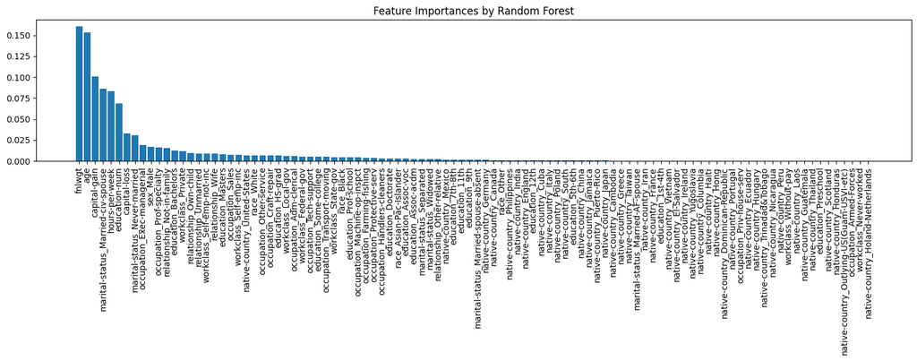

```python
# Plot Random Forest Feature Importances
feature_importances = rf_model.feature_importances_
features = X.columns
indices = np.argsort(feature_importances)[::-1]

plt.figure(figsize=(15, 6))
plt.title("Feature Importances by Random Forest")
plt.bar(range(X.shape[1]), feature_importances[indices], align="center")
plt.xticks(range(X.shape[1]), features[indices], rotation=90)
plt.tight_layout()
plt.show()
```

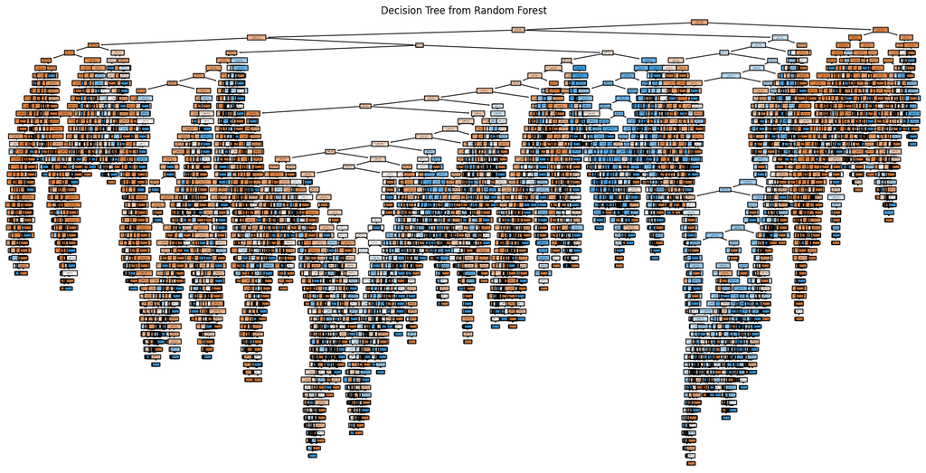

```
|--- marital-status_Never-married <= 0.37
|   |--- education_Bachelors <= 0.91
|   |   |--- marital-status_Married-civ-spouse <= 0.08
|   |   |   |--- education-num <= 1.13
|   |   |   |   |--- sex_Male <= -0.36
|   |   |   |   |   |--- education-num <= 0.55
|   |   |   |   |   |   |--- occupation_Sales <= 1.23
|   |   |   |   |   |   |   |--- capital-gain <= 0.91
|   |   |   |   |   |   |   |   |--- race_Black <= 1.39
|   |   |   |   |   |   |   |   |   |--- capital-loss <= 5.33
|   |   |   |   |   |   |   |   |   |   |--- occupation_Transport-moving <= 2.09
|   |   |   |   |   |   |   |   |   |   |   |--- truncated branch of depth 23
|   |   |   |   |   |   |   |   |   |   |--- occupation_Transport-moving >  2.09
|   |   |   |   |   |   |   |   |   |   |   |--- truncated branch of depth 5
|   |   |   |   |   |   |   |   |   |--- capital-loss >  5.33
|   |   |   |   |   |   |   |   |   |   |--- education_HS-grad <= 0.38
|   |   |   |   |   |   |   |   |   |   |   |--- class: 0.0
|   |   |   |   |   |   |   |   |   |   |--- education_HS-grad >  0.38
|   |   |   |   |   |   |   |   |   |   |   |--- truncated branch of depth 3
|   |   |   |   |   |   |   |   |--- race_Black >  1.39
|   |   |   |   |   |   |   |   |   |--- education_Some-college <= 0.66
|   |   |   |   |   |   |   |   |   |   |--- class: 0.0
|   |   |   |   |   |   |   |   |   |--- education_Some-college >  0.66
|   |   |   |   |   |   |   |   |   |   |--- occupation_Adm-clerical <= 1.22
|   |   |   |   |   |   |   |   |   |   |   |--- truncated branch of depth 3
|   |   |   |   |   |   |   |   |   |   |--- occupation_Adm-clerical >  1.22
|   |   |   |   |   |   |   |   |   |   |   |--- class: 0.0
|   |   |   |   |   |   |   |--- capital-gain >  0.91
|   |   |   |   |   |   |   |   |--- class: 1.0
|   |   |   |   |   |   |--- occupation_Sales >  1.23
|   |   |   |   |   |   |   |--- native-country_Ecuador <= 16.12
|   |   |   |   |   |   |   |   |--- native-country_Canada <= 8.32
|   |   |   |   |   |   |   |   |   |--- marital-status_Widowed <= 2.70
|   |   |   |   |   |   |   |   |   |   |--- age <= 0.58
|   |   |   |   |   |   |   |   |   |   |   |--- truncated branch of depth 8
|   |   |   |   |   |   |   |   |   |   |--- age >  0.58
|   |   |   |   |   |   |   |   |   |   |   |--- truncated branch of depth 8
|   |   |   |   |   |   |   |   |   |--- marital-status_Widowed >  2.70
|   |   |   |   |   |   |   |   |   |   |--- capital-gain <= 0.98
|   |   |   |   |   |   |   |   |   |   |   |--- truncated branch of depth 10
```

[output cut: 1170 more lines]

```
|   |   |   |   |   |--- class: 1.0
|   |   |--- workclass_State-gov >  2.33
|   |   |   |--- education_Some-college <= 0.66
|   |   |   |   |--- age <= 0.47
|   |   |   |   |   |--- education-num <= 0.94
|   |   |   |   |   |   |--- race_White <= -1.01
|   |   |   |   |   |   |   |--- class: 1.0
|   |   |   |   |   |   |--- race_White >  -1.01
|   |   |   |   |   |   |   |--- class: 0.0
|   |   |   |   |   |--- education-num >  0.94
|   |   |   |   |   |   |--- class: 0.0
|   |   |   |   |--- age >  0.47
|   |   |   |   |   |--- class: 1.0
|   |   |   |--- education_Some-college >  0.66
|   |   |   |   |--- class: 0.0
```

```python
from sklearn.tree import DecisionTreeClassifier, plot_tree, export_text


# Plot a Single Decision Tree from the Random Forest
single_tree = rf_model.estimators_[0]

plt.figure(figsize=(20, 10))
plot_tree(single_tree, feature_names=features, class_names=['<=50K', '>50K'], filled=True, rounded=True, proportion=True)
plt.title("Decision Tree from Random Forest")
plt.show()

# Print the textual representation of the tree
tree_text = export_text(single_tree, feature_names=list(features))
print(tree_text)
```

```
Logistic Regression Coefficients:
  age: 0.35473457174427414
  fnlwgt: 0.06326376779785645
  education-num: 0.575075854232503
  capital-gain: 2.276217576516782
  capital-loss: 0.2503254660870078
  hours-per-week: 0.37378388431382564
  workclass_Federal-gov: 0.1709920603395227
  workclass_Local-gov: 0.06248421401555531
  workclass_Never-worked: -0.07706035254325018
  workclass_Private: 0.21567450095243693
  workclass_Self-emp-inc: 0.128128068249622
  workclass_Self-emp-not-inc: 0.00396983922728352
  workclass_State-gov: 0.028906316223774584
  workclass_Without-pay: -0.14608737583242584
  education_11th: -0.0026290629953297446
  education_12th: 0.023193199993449345
  education_1st-4th: 0.02549775372159456
  education_5th-6th: 0.07417580658756935
  education_7th-8th: 0.014063986653275067
  education_9th: 0.011090141731671476
  education_Assoc-acdm: 0.008714776661096562
  education_Assoc-voc: 0.053614381117692
  education_Bachelors: 0.18536456066173523
  education_Doctorate: 0.0820300115118941
  education_HS-grad: 0.11017512029922177
  education_Masters: 0.13257478491502964
  education_Preschool: -0.4308829262561683
  education_Prof-school: 0.11894534259708649
  education_Some-college: 0.15590604209607825
  marital-status_Married-AF-spouse: 0.058536955729373764
  marital-status_Married-civ-spouse: 1.1043726872121364
  marital-status_Married-spouse-absent: 0.00566389394207477
  marital-status_Never-married: -0.18439061302132762
  marital-status_Separated: -0.03271080188915791
  marital-status_Widowed: 0.04939798488862671
  occupation_Adm-clerical: 0.04240358917764328
  occupation_Armed-Forces: -0.09140167238013738
  occupation_Craft-repair: 0.08146243947660606
  occupation_Exec-managerial: 0.3052446399987993
```

[output cut: 47 more lines]

```
  native-country_Outlying-US(Guam-USVI-etc): -0.10853549070793421
  native-country_Peru: -0.01894124340724705
  native-country_Philippines: 0.047479181440053454
  native-country_Poland: 0.014177179996515693
  native-country_Portugal: -0.0018529024305682469
  native-country_Puerto-Rico: -0.025132093290064904
  native-country_Scotland: 0.008919216667071654
  native-country_South: -0.1039460446135485
  native-country_Taiwan: 0.007801605518590649
  native-country_Thailand: -0.0008159831165856131
  native-country_Trinadad&Tobago: 0.002506466942487104
  native-country_United-States: 0.09167125391421667
  native-country_Vietnam: -0.043458865738938465
  native-country_Yugoslavia: 0.023797964895805178
  Intercept: -2.0962005571321156
```

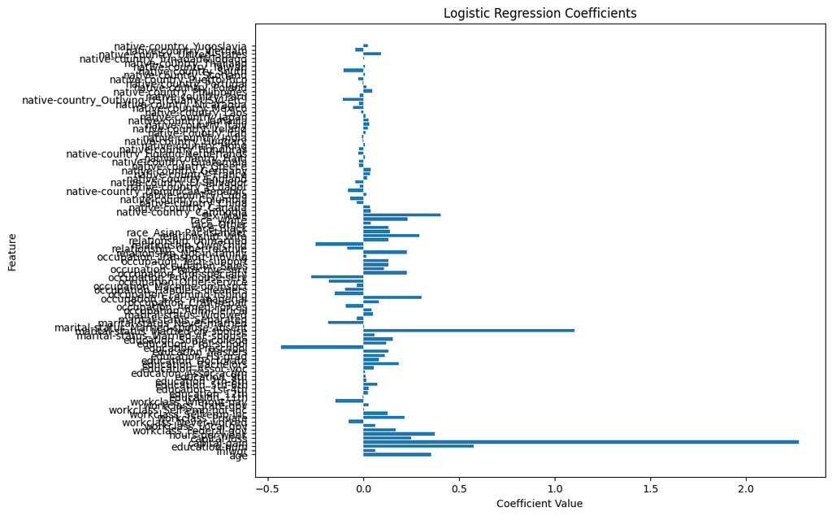

```python
# Logistic Regression Coefficients
coefficients = lr_model.coef_[0]
intercept = lr_model.intercept_[0]
features = X.columns

print('Logistic Regression Coefficients:')
for feature, coef in zip(features, coefficients):
    print(f'  {feature}: {coef}')
print(f'  Intercept: {intercept}\n')

# Plot Coefficients
plt.figure(figsize=(10, 8))
plt.barh(features, coefficients, align='center')
plt.xlabel('Coefficient Value')
plt.ylabel('Feature')
plt.title('Logistic Regression Coefficients')
plt.show()
```

### Sauvegarder le modèle pour le deployement

```python
# Save the Random Forest model for deployment
import pickle

# Save the model to a file
with open('./adult_random_forest/rf_model.pkl', 'wb') as file:
    pickle.dump(rf_model, file)

print("Random Forest model saved as 'rf_model.pkl'")

# To load the model later (example):
# with open('rf_model.pkl', 'rb') as file:
#     loaded_model = pickle.load(file)
```

```
Random Forest model saved as 'rf_model.pkl'
```

### Si vous souhaiter le réutiliser pour prédire sur de nouveau dataset.

```python
# Load the saved Random Forest model and make predictions
import pickle
import numpy as np

# Load the model from the file
with open('./adult_random_forest/rf_model.pkl', 'rb') as file:
    loaded_model = pickle.load(file)

# Example: Make predictions with new data
# Replace X_new with your actual new data
X_new = X_test  # Using X_test as an example, replace with your new data

# Make predictions
predictions = loaded_model.predict(X_new)
print("Predictions:", predictions[:10])  # Print first 10 predictions

# If you need probability scores
prediction_proba = loaded_model.predict_proba(X_new)
print("Prediction probabilities (first sample):", prediction_proba[0])
```

[output not shown]

### USE CASE 2: Méthode d'apprentissage non supervisé ( Methode de Kmeans)

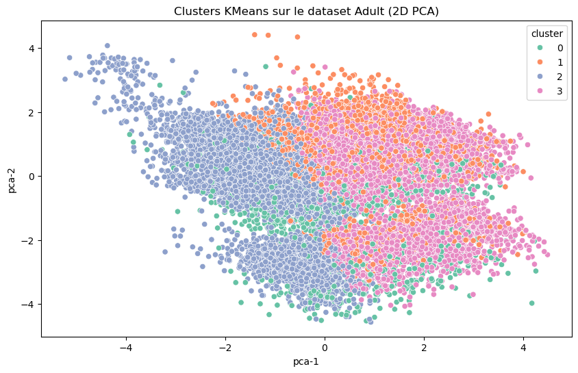

```python
import pandas as pd
from sklearn.preprocessing import StandardScaler, LabelEncoder
from sklearn.cluster import KMeans
import matplotlib.pyplot as plt
import seaborn as sns

# 1. Charger le dataset
url = 'https://archive.ics.uci.edu/ml/machine-learning-databases/adult/adult.data'
columns = [
    'age', 'workclass', 'fnlwgt', 'education', 'education-num',
    'marital-status', 'occupation', 'relationship', 'race', 'sex',
    'capital-gain', 'capital-loss', 'hours-per-week', 'native-country', 'income'
]

df = pd.read_csv(url, names=columns, na_values=' ?', skipinitialspace=True)

# 2. Nettoyage
df.dropna(inplace=True)
df.drop('income', axis=1, inplace=True)  # On ignore la cible

# Encodage des variables catégorielles
categorical_cols = df.select_dtypes(include='object').columns
df_encoded = df.copy()

le = LabelEncoder()
for col in categorical_cols:
    df_encoded[col] = le.fit_transform(df_encoded[col])

# 3. Normalisation
scaler = StandardScaler()
df_scaled = scaler.fit_transform(df_encoded)

# 4. KMeans
kmeans = KMeans(n_clusters=4, random_state=42)
df_encoded['cluster'] = kmeans.fit_predict(df_scaled)

# 5. Visualisation
# On utilise PCA pour réduire à 2D pour affichage
from sklearn.decomposition import PCA

pca = PCA(n_components=2)
pca_result = pca.fit_transform(df_scaled)

df_encoded['pca-1'] = pca_result[:, 0]
df_encoded['pca-2'] = pca_result[:, 1]

plt.figure(figsize=(10, 6))
sns.scatterplot(data=df_encoded, x='pca-1', y='pca-2', hue='cluster', palette='Set2')
plt.title('Clusters KMeans sur le dataset Adult (2D PCA)')
plt.show()
```

**Les scripts ci-après permettent d'obtenir le dataset des individus de chaque cluster.**

```python
clusters = {}
for i in range(kmeans.n_clusters):
    clusters[i] = df_encoded[df_encoded['cluster'] == i]
```

```python
for i in range(kmeans.n_clusters):
    print(f"\n--- Cluster {i} ---")
    print(clusters[i].head(3))  # affiche les 3 premières lignes
```

```
--- Cluster 0 ---
    age  workclass  fnlwgt  education  education-num  marital-status  \
4    28          4  338409          9             13               2
6    49          4  160187          6              5               3
11   30          7  141297          9             13               2

    occupation  relationship  race  sex  capital-gain  capital-loss  \
4           10             5     2    0             0             0
6            8             1     2    0             0             0
11          10             0     1    1             0             0

    hours-per-week  native-country  cluster     pca-1     pca-2
4               40               5        0  2.120241  0.586815
6               16              23        0  1.997765 -2.057724
11              40              19        0 -0.924351 -0.039039

--- Cluster 1 ---
    age  workclass  fnlwgt  education  education-num  marital-status  \
5    37          4  284582         12             14               2
19   43          6  292175         12             14               0
24   59          4  109015         11              9               0

    occupation  relationship  race  sex  capital-gain  capital-loss  \
5            4             5     4    0             0             0
19           4             4     4    0             0             0
24          13             4     4    0             0             0

    hours-per-week  native-country  cluster     pca-1     pca-2
5               40              39        1  1.438110  1.982061
19              45              39        1  0.121915  1.887654
24              40              39        1  0.246595  0.704766

--- Cluster 2 ---
   age  workclass  fnlwgt  education  education-num  marital-status  \
0   39          7   77516          9             13               4
1   50          6   83311          9             13               2
2   38          4  215646         11              9               0

   occupation  relationship  race  sex  capital-gain  capital-loss  \
0           1             1     4    1          2174             0
```

[output cut: 8 more lines]

```
--- Cluster 3 ---
    age  workclass  fnlwgt  education  education-num  marital-status  \
8    31          4   45781         12             14               4
12   23          4  122272          9             13               4
16   25          6  176756         11              9               4

    occupation  relationship  race  sex  capital-gain  capital-loss  \
8           10             1     4    0         14084             0
12           1             3     4    0             0             0
16           5             3     4    1             0             0

    hours-per-week  native-country  cluster     pca-1     pca-2
8               50              39        3 -0.218838  2.282244
12              30              39        3  2.025365  1.219637
16              35              39        3  0.719532  0.140834
```

### 🚀 Déploiement du modèle ML : Vue d'ensemble

🧱 Étapes générales :

**1.Entraîner et sauvegarder ton modèle** (.pkl, .h5, .pt, etc.)

**2.Créer une API (interface)** pour recevoir les requêtes et renvoyer les prédictions

**3.Héberger cette API sur un serveur ou dans le cloud**

**4. Facultatif : créer une interface web/app mobile qui appelle cette API**

**🔸Méthodes Classiques de deploiement**

| Outil | Pour quoi faire ? |
| --- | --- |
| Flask | API simple, parfait pour de petit projets ou tests |
| Render, Railway, Hugging Face, Heroku, etc.. | Pratique mais pas vraiment sécurisé |
| Docker | Très pratique, PRO ou Cloud |

**🔸Méthodes avancées de deploiement**

| Outil | Pour quoi faire ? |
| --- | --- |
| FastAPI | API ultra rapide et moderne (remplace Flask dans les apps sérieuses) |
| Streamlit | Créer des interfaces web interactives pour modèles ML |
| Gradio | Générer rapidement des interfaces pour tester ton modèle |
| Hugging Face Spaces | Héberger facilement un modèle NLP avec Gradio/Streamlit |
| AWS / Google Cloud / Azure | Déploiement pro, scalable, sécurisé (niveau entreprise) |